# Adatból élménybeszámoló

Tamási Árpád · ELTE TáTK

Vino Blanco, Málaga–Radazul — 2026. november

## malaga-radazul.web.app

Málaga → Radazul · okt. 27. – nov. 6. · hét fő · 908 tengeri mérföld

## Kétóránként: *pozíció, szél, tenger, ügyelet*

A közös napló · nov. 1. 18:00

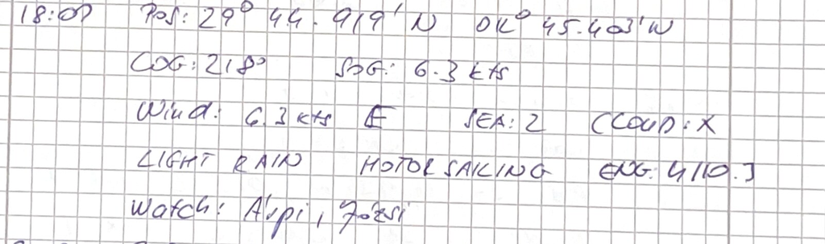

Dávid naplója · ugyanaz a sor

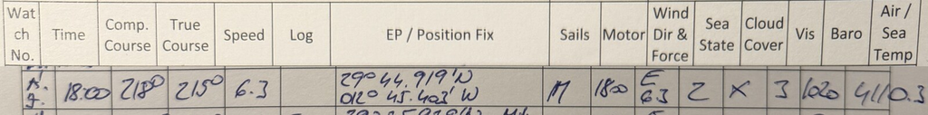

## Egy esemény, *két napló*

A közös napló · nov. 1.

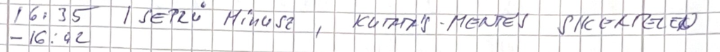

Dávid naplója · ugyanaz a nap

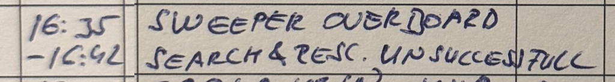

## …és *ugyanaz a fél óra*

A közös napló · nov. 1.

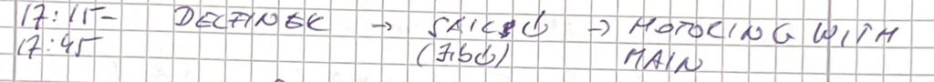

Dávid naplója · ugyanaz a nap

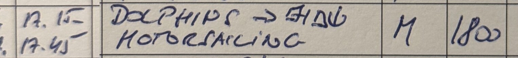

## *Sok* forrás

| A hajón | Online |
| --- | --- |
| Hajónapló, kétszer | OpenStreetMap, Natural Earth |
| Fotók, videók: Árpi, Dávid, András | AIS, meteo |
| Garmin: útvonal, Iridium | A hajó (yachting.com) |
| Bevásárlólista | Sajtó: a mentés |
|  | Szél: ECMWF-modell (Open-Meteo) |

## A lényeg: *gazdag adat*, összekötve

[figure not shown]

## Egy esemény, *több forrás*

| Esemény | Mi kötötte össze | Mit derített ki |
| --- | --- | --- |
| Delfinek | napló + két videó + András fényképezője | András gépe 2 órát sietett |
| MRCC-keresés | napló + rádióhívás a videóban + hírek | minket 40 km-re hívtak, a halálos eset 150 km-re volt |
| Befutás Radazulba | napló 15:00 + AIS 15:08 | 8 perc eltérés; a napló dátuma rossz |
| Indulás Málagából | fotók GPS-e + Dávid naplója + Garmin | a napló csak Sotograndéban kezdődött |
| Nov. 6., 13:00 | közös napló + Dávid naplója | ugyanaz az elírás: egymásból másolták |
| Seprű, szasimi | napló + a mi sztorink | ezt csak mi tudtuk |

## Azóta egy új forrás: *a szél*

Minden naplósorhoz tartozik hely és idő, ezért lekérhető, mit mondott ott és akkor az időjárási modell.

- **Forrás:** ECMWF-modell, az Open-Meteón keresztül, a térképen szélrétegként
- **Összevetés:** okt. 30., 03:00 · a napló 4 csomó ÉNy szelet ír, a modell 4,5 csomó É-t
- A modell **független** a legénységtől: ahol egyezik a naplóval, az megerősítés

malaga-radazul.web.app · jelmagyarázat: „szél, ECMWF-modell”

## A gazdagságot *a kapcsolatok* adják

Ha két *független* forrás egyezik, az megerősítés. Ha eltérnek, egy harmadik dönt.

# Élő esettanulmány

## Egy fotó a mai óráról, *kép nélkül*

Óra közben készült egy telefonfotó a teremről. A metaadataiban:

- **Hely**: GPS-koordináta, ±6 méter pontossággal
- **Irány**: merre nézett a kamera (245°, nyugat-délnyugat)
- **Idő**: tizedmásodpercre, időzónával
- **Eszköz**: telefontípus, lencse, szoftververzió, mióta nem indult újra
- **Arcok**: a telefon maga jelölte meg, hol van arc a képen

Magát a fotót nem mutatjuk: emberek vannak rajta.

## A koordinátából *térkép* lesz

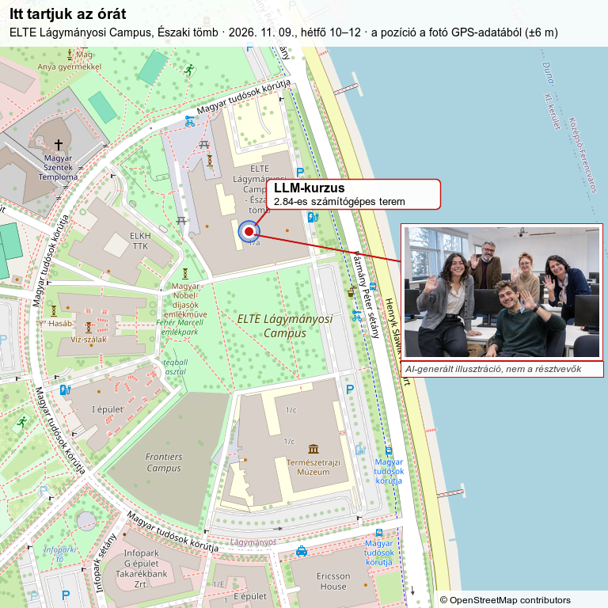

A pozíció a fotó GPS-adatából · a képen AI-generált illusztráció, nem a résztvevők · © OpenStreetMap contributors

## Hely + idő + egy nyilvános API = *új adat*

> A fotó nem mondta meg, milyen idő volt. A koordináta és az időbélyeg viszont elég ahhoz, hogy egy időjárás-API megmondja: honnan fújt a szél, és milyen erősen.
- Ugyanaz a kötés, mint a hajónaplónál: **idő és hely**
- Egyik adat sem érzékeny egyedül, az összekapcsolás teszi azzá

Erről szól a következő óra: adatbiztonság.